# Dplyr and Time Series

Christian Urcuqui

26 de febrero de 2019

[figure not shown]

# Tratamiento de datos relacionales con dplyr

Las relaciones siempre están definidas como un par de tablas, todas relacionadas a través de una o más variables. Entre algunas operaciones para datos relacionales podemos encontrar:

- Uniones, una o más variables son asignadas a un nuevo data frame desde las observaciones de otro
- filtros, se filtran observaciones de un data frame a través de una operación lógica
- conjunto de operaciones, tratamiento de observaciones basado en una operación
- Reordenar las filas
- Crear nuevas variables a partir de un conjunto de funciones y variables
- Seleccionar variables a través de sus nombres
- Resumir los valores de un conjunto de variables

Es común utilizar datos relacionados en un sistema de base de datos relacional (RDBMS), un ejemplo de estos sistemas es el que está bajo la tecnología de SQL de ORACLE. Para R podemos encontrar el paquete dplyr que nos facilita un conjunto de funciones (operaciones) sobre datos relaciones.

```r
#install.packages("tidyverse")
#install.packages("nycflights13")
#install.packages("xts")
#install.packages("PerformanceAnalytics")
library(tidyverse)
library(nycflights13)
library(xts)
library(PerformanceAnalytics)
```

Veamos las operaciones básicas que el paquete dplyr nos brinda en el dataset de vuelos

### Filtro de filas con filter()

filter() nos permite obtener un subconjunto de observaciones basado en el parametro que le ingresemos.

```
filter(Data.frame, operaciones lógicas)
```

*Ejemplo 1*

Uso de filter() para obtener los vuelos realizados entre las aerolineas terminadas en HA o B6

```r
filter(nycflights13::flights, carrier=="HA" | carrier=="B6")
```

```
## # A tibble: 54,977 x 19
##     year month   day dep_time sched_dep_time dep_delay arr_time
##    <int> <int> <int>    <int>          <int>     <dbl>    <int>
##  1  2013     1     1      544            545        -1     1004
##  2  2013     1     1      555            600        -5      913
##  3  2013     1     1      557            600        -3      838
##  4  2013     1     1      558            600        -2      849
##  5  2013     1     1      558            600        -2      853
##  6  2013     1     1      559            559         0      702
##  7  2013     1     1      600            600         0      851
##  8  2013     1     1      601            600         1      844
##  9  2013     1     1      613            610         3      925
## 10  2013     1     1      615            615         0     1039
## # ... with 54,967 more rows, and 12 more variables: sched_arr_time <int>,
## #   arr_delay <dbl>, carrier <chr>, flight <int>, tailnum <chr>,
## #   origin <chr>, dest <chr>, air_time <dbl>, distance <dbl>, hour <dbl>,
## #   minute <dbl>, time_hour <dttm>
```

*Ejercicio 1*

Obtenga los datos de los vuelos con el valor más grande en la distancia recorrida entre aeropuertos.

**Recordatorio: existen funciones del paquete base que les permiten calcular el valor mínimo y máximo de un vector**

```r
#1 linea de código
filter(nycflights13::flights, max(distance)==distance)
```

```
## # A tibble: 342 x 19
##     year month   day dep_time sched_dep_time dep_delay arr_time
##    <int> <int> <int>    <int>          <int>     <dbl>    <int>
##  1  2013     1     1      857            900        -3     1516
##  2  2013     1     2      909            900         9     1525
##  3  2013     1     3      914            900        14     1504
##  4  2013     1     4      900            900         0     1516
##  5  2013     1     5      858            900        -2     1519
##  6  2013     1     6     1019            900        79     1558
##  7  2013     1     7     1042            900       102     1620
##  8  2013     1     8      901            900         1     1504
##  9  2013     1     9      641            900      1301     1242
## 10  2013     1    10      859            900        -1     1449
## # ... with 332 more rows, and 12 more variables: sched_arr_time <int>,
## #   arr_delay <dbl>, carrier <chr>, flight <int>, tailnum <chr>,
## #   origin <chr>, dest <chr>, air_time <dbl>, distance <dbl>, hour <dbl>,
## #   minute <dbl>, time_hour <dttm>
```

```r
# -----------------------
```

*Ejercicio 2*

¿Es siempre el mismo vuelo? ¿cuáles son los orígenes y destinos?

**Recomendación: vean el significado de los códigos contra el dataset airports {nycflights13}**

R/

```r
summary(filter(nycflights13::flights, max(distance)==distance)$dest)
```

```
##    Length     Class      Mode
##       342 character character
```

```r
class(filter(nycflights13::flights, max(distance)==distance))
```

```
## [1] "tbl_df"     "tbl"        "data.frame"
```

```r
summary(factor(filter(nycflights13::flights, max(distance)==distance)$dest))
```

```
## HNL
## 342
```

```r
destino <- factor(filter(nycflights13::flights, max(distance)==distance)$dest)
summary(factor(filter(nycflights13::flights, max(distance)==distance)$origin))
```

```
## JFK
## 342
```

```r
origen <- factor(filter(nycflights13::flights, max(distance)==distance)$origin)
#filter(nycflights13::airports,faa == as.character(origen) | faa == as.character(destino))
```

Tenga cuidado al utilizar operaciones lógicas de igualdad en R. En muchas ocasiones se utiliza = en vez de ==, es usual que este inconveniente suceda por lo tanto R le notificara con un mensaje de error

*Ejemplo 2*

```r
filter(flights, month = 1)
```

```
## Error: `month` (`month = 1`) must not be named, do you need `==`?
```

Las computadoras utilizan aritmética de operación finita, es decir, no se almacenan números con infinitos números de dígitos, por lo tanto, recuerde que cada número es una aproximación. En vez de usar ==, utilice la función near() que permite comparar dos vectores con números decimales:

*Ejemplo 3*

```r
sqrt(2) ^ 2 == 2
```

```
## [1] FALSE
```

```r
near(sqrt(2) ^ 2, 2)
```

```
## [1] TRUE
```

## Operaciones lógicas

Vamos ahora a filtrar los vuelos realizados entre el mes de noviembre o diciembre a través de una forma más eficiente ya que permite realizar búsquedas mucho más especificas

*Ejemplo 4*

```r
nov_dec <- filter(flights, month %in% c(11, 12))
```

## Valores faltantes

Una caracteristica importante de R que se puede generar molestias en una comparación son los valores faltantes (missing value) o NAs (Not Availables).

*Ejemplo 5*

Observe los resultados de las operaciones que se realizan contra NA

```r
NA > 5
```

```
## [1] NA
```

```r
10 == NA
```

```
## [1] NA
```

```r
NA + 10
```

```
## [1] NA
```

```r
NA / 2
```

```
## [1] NA
```

```r
NA == NA
```

```
## [1] NA
```

Si queremos determinar si un valor es NA podemos utilizar la función is.na()

*Ejemplo 6*

```r
x <- NA
is.na(x)
```

```
## [1] TRUE
```

*Ejercicio 3*

Utilice la función filter() y obtenga los valores que no son NA

```r
x <- data.frame(c(seq(1,5), NA, seq(1,5), NA))
# 1 linea de código
filter(x, !is.na(x))
```

```
##    c.seq.1..5...NA..seq.1..5...NA.
## 1                                1
## 2                                2
## 3                                3
## 4                                4
## 5                                5
## 6                                1
## 7                                2
## 8                                3
## 9                                4
## 10                               5
```

```r
# -----------
```

Recuerde que esta misma operación la puede realizar a través del filtro sobre el mismo data frame

```
x[!is.na(x)]
```

*Ejercicio 4*

Encuentre todos los vuelos que llegaron dos o más horas tarde.

```r
# 1 linea de código
filter(flights, hour>=2)
```

```
## # A tibble: 336,775 x 19
##     year month   day dep_time sched_dep_time dep_delay arr_time
##    <int> <int> <int>    <int>          <int>     <dbl>    <int>
##  1  2013     1     1      517            515         2      830
##  2  2013     1     1      533            529         4      850
##  3  2013     1     1      542            540         2      923
##  4  2013     1     1      544            545        -1     1004
##  5  2013     1     1      554            600        -6      812
##  6  2013     1     1      554            558        -4      740
##  7  2013     1     1      555            600        -5      913
##  8  2013     1     1      557            600        -3      709
##  9  2013     1     1      557            600        -3      838
## 10  2013     1     1      558            600        -2      753
## # ... with 336,765 more rows, and 12 more variables: sched_arr_time <int>,
## #   arr_delay <dbl>, carrier <chr>, flight <int>, tailnum <chr>,
## #   origin <chr>, dest <chr>, air_time <dbl>, distance <dbl>, hour <dbl>,
## #   minute <dbl>, time_hour <dttm>
```

```r
# -----------
```

*Ejercicio 5*

Encuentre todos los vuelos que operaron con United, American, o Delta **Recomendación: revise la función grepl**

```r
filter(flights, carrier == filter(airlines, grepl("American", airlines$name))$carrier | carrier ==  filter(airlines, grepl("United", airlines$name))$carrier | carrier == filter(airlines, grepl("Delta", airlines$name))$carrier)
```

```
## # A tibble: 139,504 x 19
##     year month   day dep_time sched_dep_time dep_delay arr_time
##    <int> <int> <int>    <int>          <int>     <dbl>    <int>
##  1  2013     1     1      517            515         2      830
##  2  2013     1     1      533            529         4      850
##  3  2013     1     1      542            540         2      923
##  4  2013     1     1      554            600        -6      812
##  5  2013     1     1      554            558        -4      740
##  6  2013     1     1      558            600        -2      753
##  7  2013     1     1      558            600        -2      924
##  8  2013     1     1      558            600        -2      923
##  9  2013     1     1      559            600        -1      941
## 10  2013     1     1      559            600        -1      854
## # ... with 139,494 more rows, and 12 more variables: sched_arr_time <int>,
## #   arr_delay <dbl>, carrier <chr>, flight <int>, tailnum <chr>,
## #   origin <chr>, dest <chr>, air_time <dbl>, distance <dbl>, hour <dbl>,
## #   minute <dbl>, time_hour <dttm>
```

```r
# -----------
```

## Organización con la función arange()

La función arange() funciona de forma similar que filter() pero con la diferencia que en vez de seleccionar filas, este procederá a cambiar su orden.

La función recibe un data frame y un conjunto de nombre de variables con el objetivo de ordenarlas.

*Ejemplo 7*

En la siguiente línea de código procederemos a ordenar el data frame flights teniendo en cuenta las variables año, mes y día.

```r
arrange(flights, year, month, day)
```

```
## # A tibble: 336,776 x 19
##     year month   day dep_time sched_dep_time dep_delay arr_time
##    <int> <int> <int>    <int>          <int>     <dbl>    <int>
##  1  2013     1     1      517            515         2      830
##  2  2013     1     1      533            529         4      850
##  3  2013     1     1      542            540         2      923
##  4  2013     1     1      544            545        -1     1004
##  5  2013     1     1      554            600        -6      812
##  6  2013     1     1      554            558        -4      740
##  7  2013     1     1      555            600        -5      913
##  8  2013     1     1      557            600        -3      709
##  9  2013     1     1      557            600        -3      838
## 10  2013     1     1      558            600        -2      753
## # ... with 336,766 more rows, and 12 more variables: sched_arr_time <int>,
## #   arr_delay <dbl>, carrier <chr>, flight <int>, tailnum <chr>,
## #   origin <chr>, dest <chr>, air_time <dbl>, distance <dbl>, hour <dbl>,
## #   minute <dbl>, time_hour <dttm>
```

*Ejemplo 8*

Si queremos aplicar un ordenamiento descendiente a partir de una variable, podemos utilizar la función desc()

```r
arrange(flights, desc(arr_delay))
```

```
## # A tibble: 336,776 x 19
##     year month   day dep_time sched_dep_time dep_delay arr_time
##    <int> <int> <int>    <int>          <int>     <dbl>    <int>
##  1  2013     1     9      641            900      1301     1242
##  2  2013     6    15     1432           1935      1137     1607
##  3  2013     1    10     1121           1635      1126     1239
##  4  2013     9    20     1139           1845      1014     1457
##  5  2013     7    22      845           1600      1005     1044
##  6  2013     4    10     1100           1900       960     1342
##  7  2013     3    17     2321            810       911      135
##  8  2013     7    22     2257            759       898      121
##  9  2013    12     5      756           1700       896     1058
## 10  2013     5     3     1133           2055       878     1250
## # ... with 336,766 more rows, and 12 more variables: sched_arr_time <int>,
## #   arr_delay <dbl>, carrier <chr>, flight <int>, tailnum <chr>,
## #   origin <chr>, dest <chr>, air_time <dbl>, distance <dbl>, hour <dbl>,
## #   minute <dbl>, time_hour <dttm>
```

*Ejemplo 9*

Los missing values son siempre organizados al final de los registros.

```r
# la función tibble nos permite crear un data frame
df <- tibble(x = c(5,3,NA))
arrange(df, x)
```

```
## # A tibble: 3 x 1
##       x
##   <dbl>
## 1     3
## 2     5
## 3    NA
```

*Ejercicio 6*

¿Puede utilizar arrange() y organizar los elementos con el fin que los missing values estén al inicio de los registros?

```r
df <- tibble(x = c(5,3,NA))
# 1 linea de código
arrange(df, !is.na(x))
```

```
## # A tibble: 3 x 1
##       x
##   <dbl>
## 1    NA
## 2     5
## 3     3
```

```r
# --------------
```

*Ejercicio 7*

Organice los vuelos con el fin de encontrar el origen y destino de los 5 más retrasados

```r
# 1 linea de código
arrange(flights, desc(arr_delay))[1:5,c('origin','dest')]
```

```
## # A tibble: 5 x 2
##   origin dest
##   <chr>  <chr>
## 1 JFK    HNL
## 2 JFK    CMH
## 3 EWR    ORD
## 4 JFK    SFO
## 5 JFK    CVG
```

```r
# --------------
```

## Selección de variables con select()

La función select() nos permite obtener subconjuntos de un data frame a partir de la aplicación de operaciones que incluyen nombres de variables.

*Ejemplos 10, 11 y 12*

Selección de variables por nombre

```r
select(flights, year, month, day)
```

```
## # A tibble: 336,776 x 3
##     year month   day
##    <int> <int> <int>
##  1  2013     1     1
##  2  2013     1     1
##  3  2013     1     1
##  4  2013     1     1
##  5  2013     1     1
##  6  2013     1     1
##  7  2013     1     1
##  8  2013     1     1
##  9  2013     1     1
## 10  2013     1     1
## # ... with 336,766 more rows
```

Selección de todas las variables entre year y day

```r
select(flights, year:day)
```

```
## # A tibble: 336,776 x 3
##     year month   day
##    <int> <int> <int>
##  1  2013     1     1
##  2  2013     1     1
##  3  2013     1     1
##  4  2013     1     1
##  5  2013     1     1
##  6  2013     1     1
##  7  2013     1     1
##  8  2013     1     1
##  9  2013     1     1
## 10  2013     1     1
## # ... with 336,766 more rows
```

Seleccionamos todas las variables con excepción de las variables entre year y day

```r
select(flights, -c(year:day))
```

```
## # A tibble: 336,776 x 16
##    dep_time sched_dep_time dep_delay arr_time sched_arr_time arr_delay
##       <int>          <int>     <dbl>    <int>          <int>     <dbl>
##  1      517            515         2      830            819        11
##  2      533            529         4      850            830        20
##  3      542            540         2      923            850        33
##  4      544            545        -1     1004           1022       -18
##  5      554            600        -6      812            837       -25
##  6      554            558        -4      740            728        12
##  7      555            600        -5      913            854        19
##  8      557            600        -3      709            723       -14
##  9      557            600        -3      838            846        -8
## 10      558            600        -2      753            745         8
## # ... with 336,766 more rows, and 10 more variables: carrier <chr>,
## #   flight <int>, tailnum <chr>, origin <chr>, dest <chr>, air_time <dbl>,
## #   distance <dbl>, hour <dbl>, minute <dbl>, time_hour <dttm>
```

Existen otro conjunto de funciones que pueden ser de ayuda con la función select(), cuatro de estas son:

- starts_with(“abc”) retorna los nombres que comienzan con “abc”.
- ends_with(“xyz”) retorna los nombres que finalizan con “xyz”.
- contains(“ijk”) retorna los nombres que contienen los caracteres “ijk”.
- matches(“(.)\1”) selecciona las variables que se encuentran representadas por la expresión regular, en este caso las palabras con caracteres repetidos

*Ejemplo 13 y 14*

Podemos utilizar la función rename() que es un derivado de select() con la finalidad de cambiar los nombres de las variables.

```r
colnames(flights)
```

```
##  [1] "year"           "month"          "day"            "dep_time"
##  [5] "sched_dep_time" "dep_delay"      "arr_time"       "sched_arr_time"
##  [9] "arr_delay"      "carrier"        "flight"         "tailnum"
## [13] "origin"         "dest"           "air_time"       "distance"
## [17] "hour"           "minute"         "time_hour"
```

```r
print("----")
```

```
## [1] "----"
```

```r
colnames(rename(flights, tail_num = tailnum))
```

```
##  [1] "year"           "month"          "day"            "dep_time"
##  [5] "sched_dep_time" "dep_delay"      "arr_time"       "sched_arr_time"
##  [9] "arr_delay"      "carrier"        "flight"         "tail_num"
## [13] "origin"         "dest"           "air_time"       "distance"
## [17] "hour"           "minute"         "time_hour"
```

En la ayuda de la función select() podemos encontrar que se puede utilizar en conjunto con everything() con la finalidad mostrar todas las variables, pero, en el siguiente ejemplo veremos que es posible aplicar este proceso con el fin de ordenar las variables, es decir, para este caso aparecerán time_hour y air_time al inicio y luego las variables restantes

```r
select(flights, time_hour, air_time, everything())
```

```
## # A tibble: 336,776 x 19
##    time_hour           air_time  year month   day dep_time sched_dep_time
##    <dttm>                 <dbl> <int> <int> <int>    <int>          <int>
##  1 2013-01-01 05:00:00      227  2013     1     1      517            515
##  2 2013-01-01 05:00:00      227  2013     1     1      533            529
##  3 2013-01-01 05:00:00      160  2013     1     1      542            540
##  4 2013-01-01 05:00:00      183  2013     1     1      544            545
##  5 2013-01-01 06:00:00      116  2013     1     1      554            600
##  6 2013-01-01 05:00:00      150  2013     1     1      554            558
##  7 2013-01-01 06:00:00      158  2013     1     1      555            600
##  8 2013-01-01 06:00:00       53  2013     1     1      557            600
##  9 2013-01-01 06:00:00      140  2013     1     1      557            600
## 10 2013-01-01 06:00:00      138  2013     1     1      558            600
## # ... with 336,766 more rows, and 12 more variables: dep_delay <dbl>,
## #   arr_time <int>, sched_arr_time <int>, arr_delay <dbl>, carrier <chr>,
## #   flight <int>, tailnum <chr>, origin <chr>, dest <chr>, distance <dbl>,
## #   hour <dbl>, minute <dbl>
```

## Adicionando variables con la función mutate()

La función mutate() nos permite adicionar nuevas variables al final de nuestro data frame, veamos como creamos un conjunto de variables a partir de la operación de la selección de otras.

*Ejemplo 15*

```r
flights_sml <- select(flights,
year:day,
ends_with("delay"), # obtenemos las columnas que terminan con delay
distance,
air_time
)
# luego operamos sobre las variables del subconjunto de datos y agregamos dos columnas (gain y speed)
mutate(flights_sml,
gain = arr_delay - dep_delay,
speed = distance / air_time * 60
)
```

```
## # A tibble: 336,776 x 9
##     year month   day dep_delay arr_delay distance air_time  gain speed
##    <int> <int> <int>     <dbl>     <dbl>    <dbl>    <dbl> <dbl> <dbl>
##  1  2013     1     1         2        11     1400      227     9  370.
##  2  2013     1     1         4        20     1416      227    16  374.
##  3  2013     1     1         2        33     1089      160    31  408.
##  4  2013     1     1        -1       -18     1576      183   -17  517.
##  5  2013     1     1        -6       -25      762      116   -19  394.
##  6  2013     1     1        -4        12      719      150    16  288.
##  7  2013     1     1        -5        19     1065      158    24  404.
##  8  2013     1     1        -3       -14      229       53   -11  259.
##  9  2013     1     1        -3        -8      944      140    -5  405.
## 10  2013     1     1        -2         8      733      138    10  319.
## # ... with 336,766 more rows
```

La anterior operación es muy usual en la analítica de datos, específicamente, en minería de datos

*Ejemplo 16*

Si solo deseamos obtener las variables creadas y no enlazarlas al data frame podemos utilizar la función transmutate()

```r
transmute(flights,
gain = arr_delay - dep_delay,
hours = air_time / 60,
gain_per_hour = gain / hours
)
```

```
## # A tibble: 336,776 x 3
##     gain hours gain_per_hour
##    <dbl> <dbl>         <dbl>
##  1     9 3.78           2.38
##  2    16 3.78           4.23
##  3    31 2.67          11.6
##  4   -17 3.05          -5.57
##  5   -19 1.93          -9.83
##  6    16 2.5            6.4
##  7    24 2.63           9.11
##  8   -11 0.883        -12.5
##  9    -5 2.33          -2.14
## 10    10 2.3            4.35
## # ... with 336,766 more rows
```

## Otras funciones para creación de variables

Existen otro conjunto de funciones que podemos utilizar en conjunto con mutate(), algunas de estas son:

- Operaciones aritméticas +, -, *, /, ^

Una operación se aplicará a todos los valores de los vectores sometidos

- Operaciones aritméticas modulares (%/% y %%)

%/% para una división de enteros y %% para obtener el residuo de una división, es muy útil cuando queremos partir un entero en pedazos

```r
transmute(flights,
dep_time,
hour = dep_time %/% 100,
minute = dep_time %% 100
)[1:3,]
```

```
## # A tibble: 3 x 3
##   dep_time  hour minute
##      <int> <dbl>  <dbl>
## 1      517     5     17
## 2      533     5     33
## 3      542     5     42
```

- Logs log(), log2(), log10()

Los logartimos son ampliamente utilizados para trabajar con datos que abarcan múltiples órdenes de magnitud.

- Acumulativos

dplyr trae consigo un conjunto de funciones que permiten calcular datos acumulativos, por ejemplo, la función cummean() nos permite calcular la media acumulativa y cumsum() la suma acumulativa

```r
x <- 1:10
cumsum(x)
```

```
##  [1]  1  3  6 10 15 21 28 36 45 55
```

```r
cummean(x)
```

```
##  [1] 1.0 1.5 2.0 2.5 3.0 3.5 4.0 4.5 5.0 5.5
```

## Resumenes con la función summarize()

La función summarize() permite crear colapsar los datos de un data frame a solo una fila

*Ejemplo 19*

En el siguiente ejemplo calcularemos la media indicando que los missing values se tendrán en cuenta

```r
summarize(flights, delay = mean(dep_delay, na.rm = TRUE))
```

```
## # A tibble: 1 x 1
##   delay
##   <dbl>
## 1  12.6
```

La función summarize() se puede sacar más provecho si se utiliza en conjunto con la función group_by(), es decir, podríamos aplicar su resultado a un grupo de datos de manera individual.

*Ejemplo 20*

Veamos la aplicación de ambas funciones. En este ejemplo agruparemos el dataset a partir de las variables year, month y day, luego, procederemos a asociar la media de los retrasos de las salidas

```r
by_day <- group_by(flights, year, month, day)
summarize(by_day, delay = mean(dep_delay, na.rm = TRUE))
```

```
## # A tibble: 365 x 4
## # Groups:   year, month [?]
##     year month   day delay
##    <int> <int> <int> <dbl>
##  1  2013     1     1 11.5
##  2  2013     1     2 13.9
##  3  2013     1     3 11.0
##  4  2013     1     4  8.95
##  5  2013     1     5  5.73
##  6  2013     1     6  7.15
##  7  2013     1     7  5.42
##  8  2013     1     8  2.55
##  9  2013     1     9  2.28
## 10  2013     1    10  2.84
## # ... with 355 more rows
```

## Combinando múltiples operaciones con Pipe

Suponga que deseamos explorar la relación entre la distancia y el promedio de retrasos de cada localización. A través de las anteriores secciones podríamos desarrollar la solución con el siguiente código

```r
# agrupemos los vuelos por localización
by_dest <- group_by(flights, dest)
# apliquemos summarize y obtengamos las variables de análisis
delay <- summarize(by_dest, count = n(), dist = mean(distance, na.rm = TRUE), delay = mean(arr_delay, na.rm = TRUE))
# filtremos aquellas que sean mayores a 20 y que sean distintas a HNL
delay <- filter(delay, count > 20, dest != "HNL")
delay
```

```
## # A tibble: 96 x 4
##    dest  count  dist delay
##    <chr> <int> <dbl> <dbl>
##  1 ABQ     254 1826   4.38
##  2 ACK     265  199   4.85
##  3 ALB     439  143  14.4
##  4 ATL   17215  757. 11.3
##  5 AUS    2439 1514.  6.02
##  6 AVL     275  584.  8.00
##  7 BDL     443  116   7.05
##  8 BGR     375  378   8.03
##  9 BHM     297  866. 16.9
## 10 BNA    6333  758. 11.8
## # ... with 86 more rows
```

¿Que se sucede si generamos un plot de estos datos y observamos la relación de algunas variables?

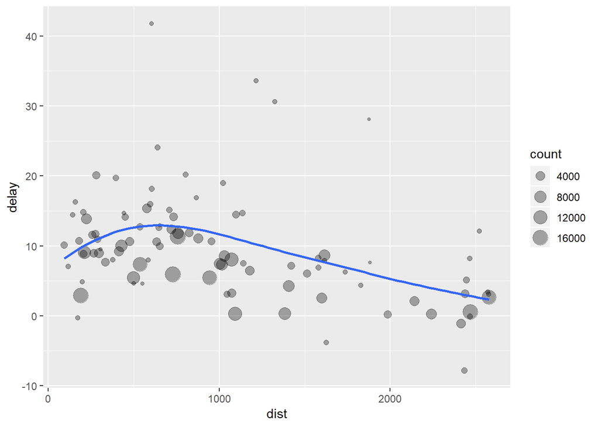

```r
ggplot(data = delay, mapping = aes(x = dist, y = delay)) +
  geom_point(aes(size = count), alpha = 1/3) +
  geom_smooth(se = FALSE)
```

Del anterior insumo podríamos presumir que los retrasos aumentan con una distancia de hasta ~ 750 millas y luego disminuyen. ¿Quizás a medida que los vuelos se hacen más largos hay más capacidad para compensar retrasos en el aire?

Podríamos también generar el mismo resultado sin necesidad de tantos pasos, esto podríamos llevarlo a cabo con pipe, %>%

```r
delays <- flights %>%
  group_by(dest) %>%
  summarize(count = n(),
            dist = mean(distance, na.rm = TRUE),
            delay = mean(arr_delay, na.rm = TRUE)) %>%
  filter(count > 20, dest!="HNL")
```

Hay que tener mucho cuidado con los missing values y la aplicación de pipe, observe que hemos usado el parámetro na.rm que permite validar este tipo de dato

```r
summary(flights)
```

```
##       year          month             day           dep_time
##  Min.   :2013   Min.   : 1.000   Min.   : 1.00   Min.   :   1
##  1st Qu.:2013   1st Qu.: 4.000   1st Qu.: 8.00   1st Qu.: 907
##  Median :2013   Median : 7.000   Median :16.00   Median :1401
##  Mean   :2013   Mean   : 6.549   Mean   :15.71   Mean   :1349
##  3rd Qu.:2013   3rd Qu.:10.000   3rd Qu.:23.00   3rd Qu.:1744
##  Max.   :2013   Max.   :12.000   Max.   :31.00   Max.   :2400
##                                                  NA's   :8255
##  sched_dep_time   dep_delay          arr_time    sched_arr_time
##  Min.   : 106   Min.   : -43.00   Min.   :   1   Min.   :   1
##  1st Qu.: 906   1st Qu.:  -5.00   1st Qu.:1104   1st Qu.:1124
##  Median :1359   Median :  -2.00   Median :1535   Median :1556
##  Mean   :1344   Mean   :  12.64   Mean   :1502   Mean   :1536
##  3rd Qu.:1729   3rd Qu.:  11.00   3rd Qu.:1940   3rd Qu.:1945
##  Max.   :2359   Max.   :1301.00   Max.   :2400   Max.   :2359
##                 NA's   :8255      NA's   :8713
##    arr_delay          carrier              flight       tailnum
##  Min.   : -86.000   Length:336776      Min.   :   1   Length:336776
##  1st Qu.: -17.000   Class :character   1st Qu.: 553   Class :character
##  Median :  -5.000   Mode  :character   Median :1496   Mode  :character
##  Mean   :   6.895                      Mean   :1972
##  3rd Qu.:  14.000                      3rd Qu.:3465
##  Max.   :1272.000                      Max.   :8500
##  NA's   :9430
##     origin              dest              air_time        distance
##  Length:336776      Length:336776      Min.   : 20.0   Min.   :  17
##  Class :character   Class :character   1st Qu.: 82.0   1st Qu.: 502
##  Mode  :character   Mode  :character   Median :129.0   Median : 872
##                                        Mean   :150.7   Mean   :1040
##                                        3rd Qu.:192.0   3rd Qu.:1389
##                                        Max.   :695.0   Max.   :4983
##                                        NA's   :9430
##       hour           minute        time_hour
##  Min.   : 1.00   Min.   : 0.00   Min.   :2013-01-01 05:00:00
##  1st Qu.: 9.00   1st Qu.: 8.00   1st Qu.:2013-04-04 13:00:00
##  Median :13.00   Median :29.00   Median :2013-07-03 10:00:00
##  Mean   :13.18   Mean   :26.23   Mean   :2013-07-03 05:22:54
##  3rd Qu.:17.00   3rd Qu.:44.00   3rd Qu.:2013-10-01 07:00:00
##  Max.   :23.00   Max.   :59.00   Max.   :2013-12-31 23:00:00
##
```

```r
flights %>%
group_by(year, month, day) %>%
summarize(mean = mean(dep_delay))
```

```
## # A tibble: 365 x 4
## # Groups:   year, month [?]
##     year month   day  mean
##    <int> <int> <int> <dbl>
##  1  2013     1     1    NA
##  2  2013     1     2    NA
##  3  2013     1     3    NA
##  4  2013     1     4    NA
##  5  2013     1     5    NA
##  6  2013     1     6    NA
##  7  2013     1     7    NA
##  8  2013     1     8    NA
##  9  2013     1     9    NA
## 10  2013     1    10    NA
## # ... with 355 more rows
```

# Manipulación de series de tiempo con XTS y ZOO

xTS (eXtensible Time Series) es un paquete que nos permite manipular datos que se encuentran registrados con base en el tiempo.

En el siguiente ejemplo crearemos una matriz con datos, un vector de fechas, luego crearemos un objeto xts que nos permitirá asociar cada registro contra los valores de las fechas.

```r
x <- matrix(1:4, ncol=2, nrow=2)
x
```

```
##      [,1] [,2]
## [1,]    1    3
## [2,]    2    4
```

```r
idx <- as.Date(c("2015-01-01", "2015-02-01"))
idx
```

```
## [1] "2015-01-01" "2015-02-01"
```

```r
X <- xts(x, order.by = idx)
X
```

```
##            [,1] [,2]
## 2015-01-01    1    3
## 2015-02-01    2    4
```

Podríamos ver el anterior resultado como las fechas son los índices que representan a los valores de cada variable de la matriz

```
xts = matrix + index
```

El constructor de xts se encuentra conformado por los siguientes parámetros

```
xts(x = NULL,
 order.by = index(x),
 frequency = NULL,
 unique = NULL,
 tzone = Sys.getenv("TZ"))
```

- tzone especifica la zona horaria de la serie de tiempo
- unique fuerza a los tiempos a ser únicos
- index es en orden ascendente en el tiempo

Con el fin de analizar los datos de un objeto xts podemos utilizar la función coredata() y la función index() para obtener los indices de la serie de tiempo

```r
coredata(x, fmt=FALSE)
```

```
##      [,1] [,2]
## [1,]    1    3
## [2,]    2    4
```

```r
index(x)
```

```
## [1] 1 2
```

Vamos a cargar un conjunto de datos sobre las manchas solares desde el año 1749 hasta 1983 que se encuentran en formato ts (time series)

```r
data(sunspots)
class(sunspots)
```

```
## [1] "ts"
```

Convirtamos los datos a xts y exploremoslos

```r
sunspots_xts <- as.xts(sunspots)
head(sunspots_xts)
```

```
##           [,1]
## ene. 1749 58.0
## feb. 1749 62.6
## mar. 1749 70.0
## abr. 1749 55.7
## may. 1749 85.0
## jun. 1749 83.5
```

Tambíen podemos inportar los datos de otras fuentes de información, por ejemplo utilizando las funciones read.table() y read.csv, lo anterior con el fin que puedan ser luego convertidos a xts.

```
as.xtx(read.table("file"))
as.xtx(read.csv("file"))
```

```
YYYY-MM-DDTHH:MM:SS
```

Es importante tener en cuenta este estándar ya que xts lo soporta

Veamos las siguientes representaciones en formatos para xts y la forma que nos facilita este paquete para hacer filtros

```r
data(edhec, package = "PerformanceAnalytics")
head(edhec)
```

```
##            Convertible Arbitrage CTA Global Distressed Securities
## 1997-01-31                0.0119     0.0393                0.0178
## 1997-02-28                0.0123     0.0298                0.0122
## 1997-03-31                0.0078    -0.0021               -0.0012
## 1997-04-30                0.0086    -0.0170                0.0030
## 1997-05-31                0.0156    -0.0015                0.0233
## 1997-06-30                0.0212     0.0085                0.0217
##            Emerging Markets Equity Market Neutral Event Driven
## 1997-01-31           0.0791                0.0189       0.0213
## 1997-02-28           0.0525                0.0101       0.0084
## 1997-03-31          -0.0120                0.0016      -0.0023
## 1997-04-30           0.0119                0.0119      -0.0005
## 1997-05-31           0.0315                0.0189       0.0346
## 1997-06-30           0.0581                0.0165       0.0258
##            Fixed Income Arbitrage Global Macro Long/Short Equity
## 1997-01-31                 0.0191       0.0573            0.0281
## 1997-02-28                 0.0122       0.0175           -0.0006
## 1997-03-31                 0.0109      -0.0119           -0.0084
## 1997-04-30                 0.0130       0.0172            0.0084
## 1997-05-31                 0.0118       0.0108            0.0394
## 1997-06-30                 0.0108       0.0218            0.0223
##            Merger Arbitrage Relative Value Short Selling Funds of Funds
## 1997-01-31           0.0150         0.0180       -0.0166         0.0317
## 1997-02-28           0.0034         0.0118        0.0426         0.0106
## 1997-03-31           0.0060         0.0010        0.0778        -0.0077
## 1997-04-30          -0.0001         0.0122       -0.0129         0.0009
## 1997-05-31           0.0197         0.0173       -0.0737         0.0275
## 1997-06-30           0.0231         0.0198       -0.0065         0.0225
```

```r
# observe que podemos realizar el filtro de la siguientes formas
print(" --------")
```

```
## [1] " --------"
```

```r
head(edhec["2007-01", 1])
```

```
##            Convertible Arbitrage
## 2007-01-31                 0.013
```

```r
print(" --------")
```

```
## [1] " --------"
```

```r
head(edhec["2007-01/2007-03",1])
```

```
##            Convertible Arbitrage
## 2007-01-31                0.0130
## 2007-02-28                0.0117
## 2007-03-31                0.0060
```

```r
print("")
```

```
## [1] ""
```

```r
head(edhec["200701/03", 1]) # similar a la anterior busqueda, obtenemos los datos desde el mes 01 hasta 03 de la primera variable ( Convertible Arbitrage)
```

```
##            Convertible Arbitrage
## 2007-01-31                0.0130
## 2007-02-28                0.0117
## 2007-03-31                0.0060
```

## Técnicas alternativas para extracción

Indexación con enteros `x[c(1, 2, 3)]`

```r
edhec[c(1, 2, 3), ]
```

```
##            Convertible Arbitrage CTA Global Distressed Securities
## 1997-01-31                0.0119     0.0393                0.0178
## 1997-02-28                0.0123     0.0298                0.0122
## 1997-03-31                0.0078    -0.0021               -0.0012
##            Emerging Markets Equity Market Neutral Event Driven
## 1997-01-31           0.0791                0.0189       0.0213
## 1997-02-28           0.0525                0.0101       0.0084
## 1997-03-31          -0.0120                0.0016      -0.0023
##            Fixed Income Arbitrage Global Macro Long/Short Equity
## 1997-01-31                 0.0191       0.0573            0.0281
## 1997-02-28                 0.0122       0.0175           -0.0006
## 1997-03-31                 0.0109      -0.0119           -0.0084
##            Merger Arbitrage Relative Value Short Selling Funds of Funds
## 1997-01-31           0.0150         0.0180       -0.0166         0.0317
## 1997-02-28           0.0034         0.0118        0.0426         0.0106
## 1997-03-31           0.0060         0.0010        0.0778        -0.0077
```

Vectores lógicos ``x[index(x)> "2016-08-20"]`

```r
edhec[index(edhec)> "2008-12-31"]
```

```
##            Convertible Arbitrage CTA Global Distressed Securities
## 2009-01-31                0.0491    -0.0016                0.0082
## 2009-02-28                0.0164    -0.0031               -0.0122
## 2009-03-31                0.0235    -0.0180                0.0022
## 2009-04-30                0.0500    -0.0140                0.0387
## 2009-05-31                0.0578     0.0213                0.0504
## 2009-06-30                0.0241    -0.0147                0.0198
## 2009-07-31                0.0611    -0.0012                0.0311
## 2009-08-31                0.0315     0.0054                0.0244
##            Emerging Markets Equity Market Neutral Event Driven
## 2009-01-31          -0.0112                0.0079       0.0132
## 2009-02-28          -0.0133               -0.0046      -0.0091
## 2009-03-31           0.0350                0.0021       0.0117
## 2009-04-30           0.0663               -0.0012       0.0337
## 2009-05-31           0.0884                0.0146       0.0442
## 2009-06-30           0.0013                0.0036       0.0123
## 2009-07-31           0.0451                0.0042       0.0291
## 2009-08-31           0.0166                0.0070       0.0207
##            Fixed Income Arbitrage Global Macro Long/Short Equity
## 2009-01-31                 0.0112       0.0029           -0.0017
## 2009-02-28                 0.0065      -0.0055           -0.0161
## 2009-03-31                 0.0057       0.0048            0.0188
## 2009-04-30                 0.0221       0.0127            0.0375
## 2009-05-31                 0.0365       0.0348            0.0516
## 2009-06-30                 0.0126      -0.0076            0.0009
## 2009-07-31                 0.0322       0.0166            0.0277
## 2009-08-31                 0.0202       0.0050            0.0157
##            Merger Arbitrage Relative Value Short Selling Funds of Funds
## 2009-01-31           0.0056         0.0100        0.0282         0.0060
## 2009-02-28           0.0006        -0.0016        0.0328        -0.0037
## 2009-03-31           0.0125         0.0100       -0.0462         0.0008
## 2009-04-30           0.0081         0.0342       -0.0820         0.0092
## 2009-05-31           0.0107         0.0392        0.0008         0.0312
## 2009-06-30           0.0104         0.0101       -0.0094         0.0024
## 2009-07-31           0.0068         0.0260       -0.0596         0.0153
## 2009-08-31           0.0102         0.0162       -0.0165         0.0113
```

Objetos Date (Date, POSIXct, etc.)

```r
dates <- as.POSIXct(c("2003-03-31", "2005-04-30"))
edhec[index(edhec)==dates]
```

```
##            Convertible Arbitrage CTA Global Distressed Securities
## 2003-03-31                0.0089    -0.0445                0.0113
## 2005-04-30               -0.0316    -0.0354               -0.0052
##            Emerging Markets Equity Market Neutral Event Driven
## 2003-03-31           0.0019                0.0015       0.0083
## 2005-04-30          -0.0049               -0.0030      -0.0128
##            Fixed Income Arbitrage Global Macro Long/Short Equity
## 2003-03-31                 0.0019      -0.0122            0.0020
## 2005-04-30                -0.0003      -0.0080           -0.0184
##            Merger Arbitrage Relative Value Short Selling Funds of Funds
## 2003-03-31          -0.0007         0.0049       -0.0075        -0.0004
## 2005-04-30          -0.0105        -0.0108        0.0393        -0.0141
```

## Métodos para encontrar periodos en nuestros datos

R implementa como funciones head() y tail() con el fin de ver los datos de inicio y final de una serie. Para nuestro caso contamos con dos funciones similares (first() y last()) en xts para el tratamiento de tiempo.

```r
first(edhec[, "Funds of Funds"])
```

```
##            Funds of Funds
## 1997-01-31         0.0317
```

```r
print(" -------- ")
```

```
## [1] " -------- "
```

```r
first(edhec[, "Funds of Funds"], "4 months")
```

```
##            Funds of Funds
## 1997-01-31         0.0317
## 1997-02-28         0.0106
## 1997-03-31        -0.0077
## 1997-04-30         0.0009
```

```r
print(" -------- ")
```

```
## [1] " -------- "
```

```r
first(edhec[, "Funds of Funds"], "2 days")
```

```
##            Funds of Funds
## 1997-01-31         0.0317
## 1997-02-28         0.0106
```

```r
print(" -------- ")
```

```
## [1] " -------- "
```

```r
last(edhec[, "Funds of Funds"], "1 year")
```

```
##            Funds of Funds
## 2009-01-31         0.0060
## 2009-02-28        -0.0037
## 2009-03-31         0.0008
## 2009-04-30         0.0092
## 2009-05-31         0.0312
## 2009-06-30         0.0024
## 2009-07-31         0.0153
## 2009-08-31         0.0113
```

```r
# también podemos encontrar periodos con enteros
print(" -------- ")
```

```
## [1] " -------- "
```

```r
first(edhec, n=2, keep= FALSE)
```

```
##            Convertible Arbitrage CTA Global Distressed Securities
## 1997-01-31                0.0119     0.0393                0.0178
## 1997-02-28                0.0123     0.0298                0.0122
##            Emerging Markets Equity Market Neutral Event Driven
## 1997-01-31           0.0791                0.0189       0.0213
## 1997-02-28           0.0525                0.0101       0.0084
##            Fixed Income Arbitrage Global Macro Long/Short Equity
## 1997-01-31                 0.0191       0.0573            0.0281
## 1997-02-28                 0.0122       0.0175           -0.0006
##            Merger Arbitrage Relative Value Short Selling Funds of Funds
## 1997-01-31           0.0150         0.0180       -0.0166         0.0317
## 1997-02-28           0.0034         0.0118        0.0426         0.0106
```

Podemos también combinar ambas funciones para realizar filtros más exhaustivos

```r
first(last(edhec[, "Merger Arbitrage"], "2 years"), "5 months")
```

```
##            Merger Arbitrage
## 2008-01-31          -0.0126
## 2008-02-29           0.0060
## 2008-03-31          -0.0045
## 2008-04-30           0.0149
## 2008-05-31           0.0136
```

## Operaciones entre objetos xts

Como hemos mencionado xts es una matrix y es por ello que sus elementos pueden ser tratados, en el caso de fechas las operaciones matemáticas son intersecciones de tiempos

Vamos a realizar las siguientes operaciones entre objetos xts con el fin que pueda observar sus resultados.

```r
x <- c(rep(1, 3))
y <- c(rep(2, 3))
idx <- as.Date(c("2016-08-09", "2016-08-10", "2016-08-11"))
idy <- as.Date(c("2016-08-09", "2016-08-10", "2016-08-12"))
X <- xts(x, order.by = idx)
Y <- xts(y, order.by = idy)

X + Y # intersección de fechas
```

```
##            e1
## 2016-08-09  3
## 2016-08-10  3
```

```r
print(" ------- ")
```

```
## [1] " ------- "
```

```r
# si deseamos obtener todos los registros
x_union <- merge(X, index(Y), fill=0)
y_union <- merge(Y, index(X), fill = 0)
x_union + y_union
```

```
##            X
## 2016-08-09 3
## 2016-08-10 3
## 2016-08-11 1
## 2016-08-12 2
```

## Fusionando series de tiempo

Podemos combinar series por columna a través de las funciones cbind() y merge(), entre estas combinaciones podemos encontrar de derecha, izquierda, interiores y exteriores.

```r
X
```

```
##            [,1]
## 2016-08-09    1
## 2016-08-10    1
## 2016-08-11    1
```

```r
print(" -------- ")
```

```
## [1] " -------- "
```

```r
Y
```

```
##            [,1]
## 2016-08-09    2
## 2016-08-10    2
## 2016-08-12    2
```

```r
print(" -------- ")
```

```
## [1] " -------- "
```

```r
merge(X, Y) # Join por defecto "outer"
```

```
##             X  Y
## 2016-08-09  1  2
## 2016-08-10  1  2
## 2016-08-11  1 NA
## 2016-08-12 NA  2
```

```r
print(" -------- ")
```

```
## [1] " -------- "
```

```r
merge(X, Y, join = "inner")
```

```
##            X Y
## 2016-08-09 1 2
## 2016-08-10 1 2
```

```r
print(" -------- ")
```

```
## [1] " -------- "
```

```r
merge(X, Y, join = "right", fill = na.locf) # se autocompleta el NA
```

```
##            X Y
## 2016-08-09 1 2
## 2016-08-10 1 2
## 2016-08-12 1 2
```

```r
print(" -------- ")
```

```
## [1] " -------- "
```

```r
merge(X, 3)
```

```
##            X X3
## 2016-08-09 1  3
## 2016-08-10 1  3
## 2016-08-11 1  3
```

```r
print(" -------- ")
```

```
## [1] " -------- "
```

```r
merge(X, as.Date(c("2016-08-14")))
```

```
##             X
## 2016-08-09  1
## 2016-08-10  1
## 2016-08-11  1
## 2016-08-14 NA
```

También podemos hacer las inserciones por filas a través de la función rbind(). Hay que anotar que todas las filas deben tener un orden de tiempo y el número de variables debe coincidir.

```r
rbind(X, Y)
```

```
##            [,1]
## 2016-08-09    1
## 2016-08-09    2
## 2016-08-10    1
## 2016-08-10    2
## 2016-08-11    1
## 2016-08-12    2
```

Note que se pueden repetir filas con los registros.

## Gestionando missing values en series de tiempo

Podemos realizar un relleno de missing values con la última observación a través de la función locf (last observation carried forward)

```r
object <- merge(X, Y)
na.locf(object,
       fromLast = FALSE,
       maxgap = Inf)
```

```
##            X Y
## 2016-08-09 1 2
## 2016-08-10 1 2
## 2016-08-11 1 2
## 2016-08-12 1 2
```

Reemplazar missing values

```r
na.fill(object, 5)
```

```
##            X Y
## 2016-08-09 1 2
## 2016-08-10 1 2
## 2016-08-11 1 5
## 2016-08-12 5 2
```

Remover missing values

```r
na.trim(object)
```

```
##            X Y
## 2016-08-09 1 2
## 2016-08-10 1 2
```

```r
na.omit(object)
```

```
##            X Y
## 2016-08-09 1 2
## 2016-08-10 1 2
```

Interpolación

```
na.approx(object, ...)
```

# Taller

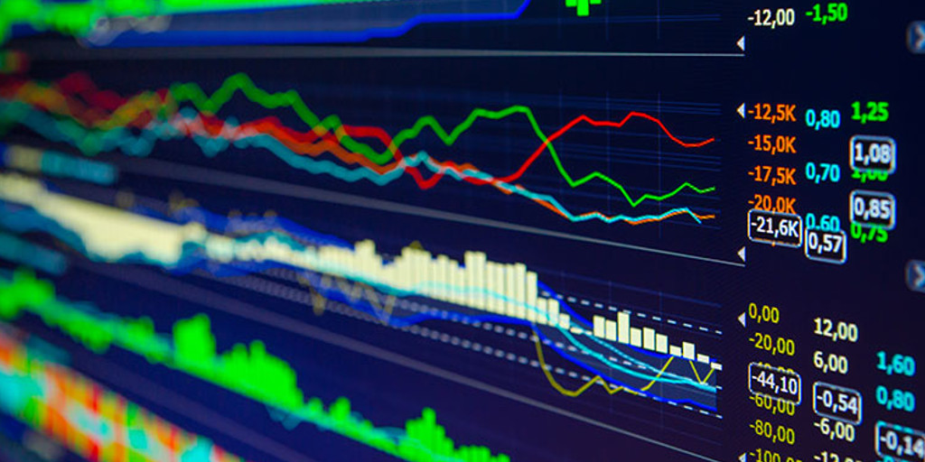

Aplique los conceptos vistos en el dataset del portafolio https://www.dropbox.com/s/fd1064pxz1ss72g/datos.RData?dl=0

```r
# vamos a cargar el archivo RData
load(file.choose())
```

```r
# vamos a prepocesar los dato, por favor ejecute las siguientes lineas de código
datos.provicionales <- t(datos) # se crea una base de datos provicional para generar el data frame donde las filas sean las fechas y las columnas las acciones deseadas
names <- t(datos[1])
datos.provicionales <- as.data.frame(datos.provicionales)
datos.provicionales <- datos.provicionales[-1,]
names(datos.provicionales)<-names
PORTAFOLIO <- datos.provicionales[c("GRUPOSURA", "ECOPETROL", "NUTRESA", "EXITO", "ISA", "GRUPOAVAL", "PFAVH", "CONCONCRET", "VALOREM", "OCCIDENTE")]

names <-c ("GRUPOSURA", "ECOPETROL", "NUTRESA", "EXITO", "ISA", "GRUPOAVAL", "AVIANCA", "CONCONCRETO", "VALOREM", "OCCIDENTE")

names(PORTAFOLIO) <- names

# se tiene que cambiar la clase de los columnas del data.frame PORTAFOLIO
indx <- sapply(PORTAFOLIO, is.factor)
PORTAFOLIO[indx] <- lapply(PORTAFOLIO[indx], function(x) as.numeric(as.character(x)))
dates <- as.Date(row.names(PORTAFOLIO))
#se crea un objeto  xts
PORTAFOLIO2 <- xts(x=PORTAFOLIO, order.by=dates)

no.Acciones <- matrix(c(156, 2000, 378, 998, 1983, 92468, 922, 1367, 651, 7943), 10, 1)

resumen        <- as.data.frame(cbind(names, no.Acciones, t(tail(PORTAFOLIO2, 1)), no.Acciones * t(tail(PORTAFOLIO2, 1))))
resumen[,2] <- as.numeric(as.character(resumen[,2] ))
resumen[,3] <- as.numeric(as.character(resumen[,3] ))
resumen[,4] <- as.numeric(as.character(resumen[,4] ))
resumen[,5] <- resumen[,4]/sum(resumen[,4]) *100
names(resumen) <-  c("Nombre", "No. de Acciones", "Precio", "P*Q", "Part. %")
prices_daily <- PORTAFOLIO2 # crea serie diario
asset_returns_diario <- Return.calculate(prices_daily, method = "log")*100 # calcula los rendimientos

resumen.diario     <- as.data.frame(cbind(t(tail(asset_returns_diario, 3))))
```

Vamos a crear un plot con el fin que pueda inferir visualmente algunas cosas de los datos con el fin que pueda resolverlas en las siguientes clases.

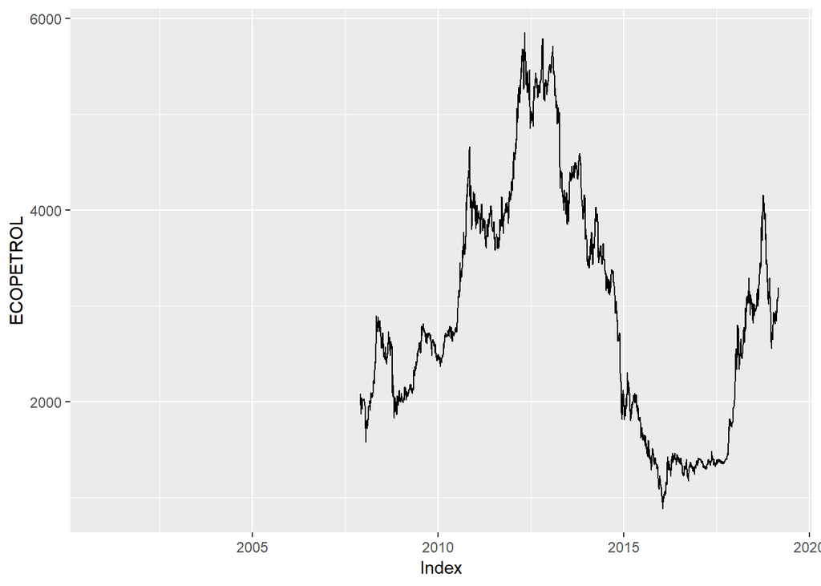

```r
#ggplot(data = PORTAFOLIO, aes(x = rownames(PORTAFOLIO), y = ECOPETROL))+
#  geom_line(color = "#00AFBB", size = 2)

autoplot(PORTAFOLIO2[, "ECOPETROL"], ts.colour = 'green', na.rm = TRUE)
```

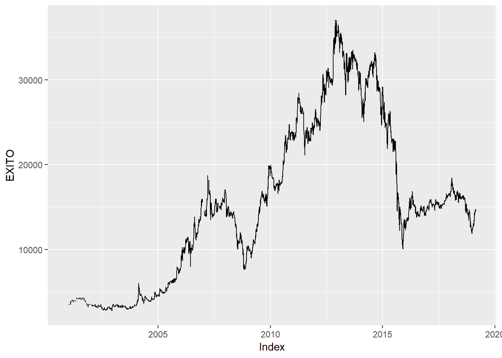

```r
autoplot(PORTAFOLIO2[, "EXITO"], ts.colour = 'green', na.rm = TRUE)
```

- ¿Que problemas se presentan?
- Proponga una solución y aplíquela
- Ejecute en R el mecanismo que permita obtener los primeros y los últimos cinco meses de ECOPETROL
- Ejecute un script en R que permita obtener el máximo valor de la serie de tiempo tanto de ECOPETROL y el EXITO

# Referencias

- Wickham, H., & Grolemund, Garrett. (2016). R for Data Science. O´Relly
- Time Series Data in R with xts & zoo